# Impact of severe weather events on the U.S. population health and economy

#### Second Objective

In the next segment, we will perform necessary steps to answer the objective of finding out, which types of weather events have the greatest economic consequences.

Looking closely at the variables, we notice that to answer this question, there are two variables of interest namely, `PROPDMG` and `CROPDMG` which we will be looking into more closely.

Now, the variables, `PROPDMGEXP` and `CROPDMGEXP` have different values which we can observe from the following code segments. For `PROPDMGEXP` we see the following exponent values, here we have decided to use the following strategy, from the variable descriptions in the codebook and some assumptions

```
 '-' or '+' or ""  -  Leave PROPDMG as it is
 '0' - '7'         -  Multiply PROPDMG by 1eN i.e, 10^N where N belongs to {0,2,3,4,5,6,7}
 'B'               -  Multiply PROPDMG by 1e9 i.e, 10^9
 'h' or 'H'        -  Multiply PROPDMG by 1e2 i.e, 100
 'K'               -  Multiply PROPDMG by 1e3 i.e, 1000
 'm' or 'M'        -  Multiply PROPDMG by 1e6 i.e, 10^6
```

We take the multipliers based on the distinct exponent labels shown in the code segment below.

```r
t <- table(stormDataSubset$PROPDMGEXP)
names(t) <- c("\"\"", "-", "+", "0", "2", "3", "4", "5", "6", "7", "B", "h", "H", "K", "m", "M")
pandoc.table(t, style = "grid", justify = "left", caption = "PROPDMGEXP label frequencies")
```

```
+-------+-----+-----+-----+-----+-----+-----+-----+-----+-----+-----+
| ""    | -   | +   | 0   | 2   | 3   | 4   | 5   | 6   | 7   | B   |
+=======+=====+=====+=====+=====+=====+=====+=====+=====+=====+=====+
| 11585 | 1   | 5   | 210 | 1   | 1   | 4   | 18  | 3   | 3   | 40  |
+-------+-----+-----+-----+-----+-----+-----+-----+-----+-----+-----+

Table: PROPDMGEXP label frequencies (continued below)



+-----+-----+--------+-----+-------+
| h   | H   | K      | m   | M     |
+=====+=====+========+=====+=======+
| 1   | 6   | 231428 | 7   | 11320 |
+-----+-----+--------+-----+-------+
```

For `CROPDMGEXP` we see the following exponent values, here we have decided to use the following strategy, from the variable descriptions in the codebook and some assumptions

```
 '?' or ""  -  Leave CROPDMG as it is
 '0'        -  Multiply CROPDMG by 1eN i.e, 10^N where N belongs to {0}
 'B'        -  Multiply CROPDMG by 1e9 i.e, 10^9
 'k' or 'K' -  Multiply CROPDMG by 1e3 i.e, 1000
 'm' or 'M' -  Multiply CROPDMG by 1e6 i.e, 10^6
```

We take the multipliers based on the distinct exponent labels shown in the code segment below.

```r
t <- table(stormDataSubset$CROPDMGEXP)
names(t) <- c("\"\"", "?", "0", "B", "k", "K", "m", "M")
pandoc.table(t, style = "grid", justify = "left", caption = "CROPDMGEXP label frequencies")
```

```
+--------+-----+-----+-----+-----+-------+-----+------+
| ""     | ?   | 0   | B   | k   | K     | m   | M    |
+========+=====+=====+=====+=====+=======+=====+======+
| 152664 | 6   | 17  | 7   | 21  | 99932 | 1   | 1985 |
+--------+-----+-----+-----+-----+-------+-----+------+

Table: CROPDMGEXP label frequencies
```

Now we transform the values of `PROPDMGEXP` based on the key to proper numeric multipliers in the following code segment.

```r
multiplierKey <- c(`-` = 1, `+` = 1, `0` = 1, `2` = 100, `3` = 1000, `4` = 10000, `5` = 100000, `6` = 1000000,
    `7` = 10000000, B = 1000000000, h = 100, H = 100, K = 1000, m = 1000000, M = 1000000)

propdmgMultiplier <- multiplierKey[as.character(stormDataSubset$PROPDMGEXP)]

propdmgMultiplier[is.na(propdmgMultiplier)] <- 1

pandoc.table(table(propdmgMultiplier), style = "grid", justify = "left", caption = "Property damage multiplier value frequencies")
```

```
+-------+-------+--------+---------+----------+-----------+------------+
| 1     | 100   | 1000   | 10000   | 100000   | 1000000   | 10000000   |
+=======+=======+========+=========+==========+===========+============+
| 11801 | 8     | 231429 | 4       | 18       | 11330     | 3          |
+-------+-------+--------+---------+----------+-----------+------------+

Table: Property damage multiplier value frequencies (continued below)



+--------------+
| 1000000000   |
+==============+
| 40           |
+--------------+
```

After getting the multiplier values above, we multiply it with the respective `PROPDMG` values to obtain the actual value of property damage caused by the different weather event types.

```r
stormDataSubset$propertyDamage <- stormDataSubset$PROPDMG * propdmgMultiplier

propertyDamages <- aggregate(propertyDamage ~ EVTYPE, data = stormDataSubset, FUN = sum)

propertyDamages <- propertyDamages[propertyDamages$propertyDamage > 0, ]

str(propertyDamages)
```

```
'data.frame':   406 obs. of  2 variables:
 $ EVTYPE        : chr  "   HIGH SURF ADVISORY" " FLASH FLOOD" " TSTM WIND" " TSTM WIND (G45)" ...
 $ propertyDamage: num  200000 50000 8100000 8000 5000 ...
```

Now we transform the values of `CROPDMGEXP` based on the key to proper numeric multipliers in the following code segment.

```r
multiplierKey <- c(`?` = 1, `0` = 1, B = 1000000000, k = 1000, K = 1000, m = 1000000, M = 1000000)

cropdmgMultiplier <- multiplierKey[as.character(stormDataSubset$CROPDMGEXP)]

cropdmgMultiplier[is.na(cropdmgMultiplier)] <- 1

pandoc.table(table(cropdmgMultiplier), style = "grid", justify = "left", caption = "Crop damage multiplier value frequencies")
```

```
+--------+--------+-----------+--------------+
| 1      | 1000   | 1000000   | 1000000000   |
+========+========+===========+==============+
| 152687 | 99953  | 1986      | 7            |
+--------+--------+-----------+--------------+

Table: Crop damage multiplier value frequencies
```

```r
stormDataSubset$cropDamage <- stormDataSubset$CROPDMG * cropdmgMultiplier

cropDamages <- aggregate(cropDamage ~ EVTYPE, data = stormDataSubset, FUN = sum)

cropDamages <- cropDamages[cropDamages$cropDamage > 0, ]

str(cropDamages)
```

```
'data.frame':   136 obs. of  2 variables:
 $ EVTYPE    : chr  "AGRICULTURAL FREEZE" "BLIZZARD" "COASTAL FLOODING" "COLD AIR TORNADO" ...
 $ cropDamage: num  28820000 112060000 56000 50 66000000 ...
```

## Analysis and Results

In this section, we will be analyzing the data we transformed and prepared in the previous section to answer the questions pertaining to our two main objectives. First, we will try to analyze the data to answer our first objective, which is to find out which weather event types affect population health the most.

The following code segment shows us the top ten weather event types, which have been responsible for causing the most population injuries in the U.S.

```r
injuries <- totalInjuries[order(totalInjuries$INJURIES, decreasing = T), ][1:10, ]
row.names(injuries) <- NULL
pandoc.table(injuries, style = "grid", justify = "left", caption = "Top ten weather events causing most injuries")
```

```
+-------------------+------------+
| EVTYPE            | INJURIES   |
+===================+============+
| TORNADO           | 91346      |
+-------------------+------------+
| TSTM WIND         | 6957       |
+-------------------+------------+
| FLOOD             | 6789       |
+-------------------+------------+
| EXCESSIVE HEAT    | 6525       |
+-------------------+------------+
| LIGHTNING         | 5230       |
+-------------------+------------+
| HEAT              | 2100       |
+-------------------+------------+
| ICE STORM         | 1975       |
+-------------------+------------+
| FLASH FLOOD       | 1777       |
+-------------------+------------+
| THUNDERSTORM WIND | 1488       |
+-------------------+------------+
| HAIL              | 1361       |
+-------------------+------------+

Table: Top ten weather events causing most injuries
```

From the above table, we see that `TORNADO` is the most harmful weather event causing maximum number of injuries.

The following code segment shows us the top ten weather event types, which have been responsible for causing the most population fatalities in the U.S.

```r
fatalities <- totalFatalities[order(totalFatalities$FATALITIES, decreasing = T), ][1:10, ]
row.names(fatalities) <- NULL
pandoc.table(fatalities, style = "grid", justify = "left", caption = "Top ten weather events causing most fatalities")
```

```
+----------------+--------------+
| EVTYPE         | FATALITIES   |
+================+==============+
| TORNADO        | 5633         |
+----------------+--------------+
| EXCESSIVE HEAT | 1903         |
+----------------+--------------+
| FLASH FLOOD    | 978          |
+----------------+--------------+
| HEAT           | 937          |
+----------------+--------------+
| LIGHTNING      | 816          |
+----------------+--------------+
| TSTM WIND      | 504          |
+----------------+--------------+
| FLOOD          | 470          |
+----------------+--------------+
| RIP CURRENT    | 368          |
+----------------+--------------+
| HIGH WIND      | 248          |
+----------------+--------------+
| AVALANCHE      | 224          |
+----------------+--------------+

Table: Top ten weather events causing most fatalities
```

Now we combine the above two parameters, namely `INJURIES` and `FATALITIES` to also get the total damage caused by the different weather event types and sort them based on the total casualties which have been caused by the weather events and display the top ten most harmful weather event types on population health.

```r
healthData <- aggregate(cbind(FATALITIES, INJURIES) ~ EVTYPE, data = stormDataSubset, FUN = sum)
TOTAL <- healthData$FATALITIES + healthData$INJURIES
healthData <- cbind(healthData, TOTAL)
healthData <- healthData[order(healthData$TOTAL, decreasing = T), ]
topTenHealth <- healthData[1:10, ]
row.names(topTenHealth) <- NULL
pandoc.table(topTenHealth, style = "grid", justify = "left", caption = "Top ten weather events having harmful effects on population health")
```

```
+-------------------+--------------+------------+---------+
| EVTYPE            | FATALITIES   | INJURIES   | TOTAL   |
+===================+==============+============+=========+
| TORNADO           | 5633         | 91346      | 96979   |
+-------------------+--------------+------------+---------+
| EXCESSIVE HEAT    | 1903         | 6525       | 8428    |
+-------------------+--------------+------------+---------+
| TSTM WIND         | 504          | 6957       | 7461    |
+-------------------+--------------+------------+---------+
| FLOOD             | 470          | 6789       | 7259    |
+-------------------+--------------+------------+---------+
| LIGHTNING         | 816          | 5230       | 6046    |
+-------------------+--------------+------------+---------+
| HEAT              | 937          | 2100       | 3037    |
+-------------------+--------------+------------+---------+
| FLASH FLOOD       | 978          | 1777       | 2755    |
+-------------------+--------------+------------+---------+
| ICE STORM         | 89           | 1975       | 2064    |
+-------------------+--------------+------------+---------+
| THUNDERSTORM WIND | 133          | 1488       | 1621    |
+-------------------+--------------+------------+---------+
| WINTER STORM      | 206          | 1321       | 1527    |
+-------------------+--------------+------------+---------+

Table: Top ten weather events having harmful effects on population health
```

From the above table, we see that the top three weather event types most harmful to the population health are, `TORNADO`, `EXCESSIVE HEAT` and `TSTM WIND`.

The following code segment, plots a figure depicting the top ten most harmful weather events to the U.S. population health.

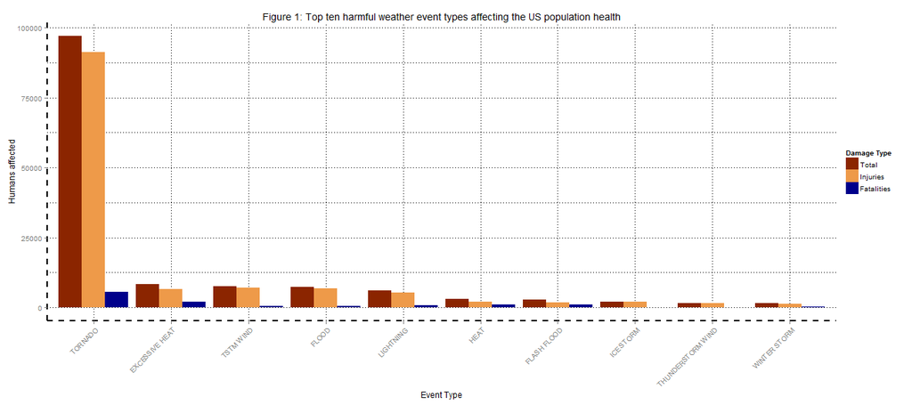

```r
plotHealth <- melt(topTenHealth[, c("EVTYPE", "TOTAL", "INJURIES", "FATALITIES")], id.vars = 1)

ggplot(plotHealth, aes(x = reorder(EVTYPE, -value), y = value)) + geom_bar(stat = "identity", aes(fill = variable),
    position = "dodge") + theme(axis.text.x = element_text(angle = 45, hjust = 1), axis.line = element_line(size = 1,
    colour = "black", linetype = "dashed"), panel.background = element_rect(fill = "white"), panel.grid.major = element_line(colour = "black",
    linetype = "dotted"), panel.grid.minor = element_line(colour = "black", linetype = "dotted"), panel.background = element_rect(fill = "white")) +
    xlab("Event Type") + ylab("Humans affected") + ggtitle("Figure 1: Top ten harmful weather event types affecting the US population health") +
    scale_fill_manual(name = "Damage Type", values = c("orangered4", "tan2", "darkblue"), labels = c("Total",
        "Injuries", "Fatalities"))
```

Looking at the above plot, we can deduce the following conclusions.

[output not shown]

Now, we will try to analyze the data to answer our second objective, which is to find out which weather event types affect the U.S. economy the most.

The following code segment shows us the top ten weather event types, which have been responsible for causing the most property damage in the U.S.

```r
propdmg <- propertyDamages[order(propertyDamages$propertyDamage, decreasing = T), ][1:10, ]
row.names(propdmg) <- NULL
pandoc.table(propdmg, style = "grid", justify = "left", caption = "Top ten weather events causing most damage to property")
```

```
+-------------------+------------------+
| EVTYPE            | propertyDamage   |
+===================+==================+
| FLOOD             | 144657709807     |
+-------------------+------------------+
| HURRICANE/TYPHOON | 69305840000      |
+-------------------+------------------+
| TORNADO           | 56947380677      |
+-------------------+------------------+
| STORM SURGE       | 43323536000      |
+-------------------+------------------+
| FLASH FLOOD       | 16822673979      |
+-------------------+------------------+
| HAIL              | 15735267513      |
+-------------------+------------------+
| HURRICANE         | 11868319010      |
+-------------------+------------------+
| TROPICAL STORM    | 7703890550       |
+-------------------+------------------+
| WINTER STORM      | 6688497251       |
+-------------------+------------------+
| HIGH WIND         | 5270046295       |
+-------------------+------------------+

Table: Top ten weather events causing most damage to property
```

From the above table, we see that `FLOOD` is the most harmful weather event causing the maximum damage to property.

The following code segment shows us the top ten weather event types, which have been responsible for causing the most crop damage in the U.S.

```r
cropdmg <- cropDamages[order(cropDamages$cropDamage, decreasing = T), ][1:10, ]
row.names(cropdmg) <- NULL
pandoc.table(cropdmg, style = "grid", justify = "left", caption = "Top ten weather events causing most damage to crops")
```

```
+-------------------+--------------+
| EVTYPE            | cropDamage   |
+===================+==============+
| DROUGHT           | 13972566000  |
+-------------------+--------------+
| FLOOD             | 5661968450   |
+-------------------+--------------+
| RIVER FLOOD       | 5029459000   |
+-------------------+--------------+
| ICE STORM         | 5022113500   |
+-------------------+--------------+
| HAIL              | 3025954473   |
+-------------------+--------------+
| HURRICANE         | 2741910000   |
+-------------------+--------------+
| HURRICANE/TYPHOON | 2607872800   |
+-------------------+--------------+
| FLASH FLOOD       | 1421317100   |
+-------------------+--------------+
| EXTREME COLD      | 1292973000   |
+-------------------+--------------+
| FROST/FREEZE      | 1094086000   |
+-------------------+--------------+

Table: Top ten weather events causing most damage to crops
```

From the above table, we see that `DROUGHT` is the most harmful weather event causing the maximum damage to crops.

Now we combine the above two parameters, namely `propertyDamage` and `cropDamage` to also get the total damage caused by the different weather event types and sort them based on the total cost in dollars which have been caused due to damage, by the weather events and display the top ten most harmful weather event types on the economy.

```r
economyData <- aggregate(cbind(propertyDamage, cropDamage) ~ EVTYPE, data = stormDataSubset, FUN = sum)
totalDamage <- economyData$propertyDamage + economyData$cropDamage
economyData <- cbind(economyData, totalDamage)
economyData <- economyData[order(economyData$totalDamage, decreasing = T), ]
topTenEconomy <- economyData[1:10, ]
row.names(topTenEconomy) <- NULL
pandoc.table(topTenEconomy, style = "grid", justify = "left", caption = "Top ten weather events having harmful effects on economy")
```

```
+-------------------+------------------+--------------+---------------+
| EVTYPE            | propertyDamage   | cropDamage   | totalDamage   |
+===================+==================+==============+===============+
| FLOOD             | 144657709807     | 5661968450   | 150319678257  |
+-------------------+------------------+--------------+---------------+
| HURRICANE/TYPHOON | 69305840000      | 2607872800   | 71913712800   |
+-------------------+------------------+--------------+---------------+
| TORNADO           | 56947380677      | 414953270    | 57362333947   |
+-------------------+------------------+--------------+---------------+
| STORM SURGE       | 43323536000      | 5000         | 43323541000   |
+-------------------+------------------+--------------+---------------+
| HAIL              | 15735267513      | 3025954473   | 18761221986   |
+-------------------+------------------+--------------+---------------+
| FLASH FLOOD       | 16822673979      | 1421317100   | 18243991079   |
+-------------------+------------------+--------------+---------------+
| DROUGHT           | 1046106000       | 13972566000  | 15018672000   |
+-------------------+------------------+--------------+---------------+
| HURRICANE         | 11868319010      | 2741910000   | 14610229010   |
+-------------------+------------------+--------------+---------------+
| RIVER FLOOD       | 5118945500       | 5029459000   | 10148404500   |
+-------------------+------------------+--------------+---------------+
| ICE STORM         | 3944927860       | 5022113500   | 8967041360    |
+-------------------+------------------+--------------+---------------+

Table: Top ten weather events having harmful effects on economy
```

The following code segment, plots a figure depicting the top ten most harmful weather events to the U.S. economy.

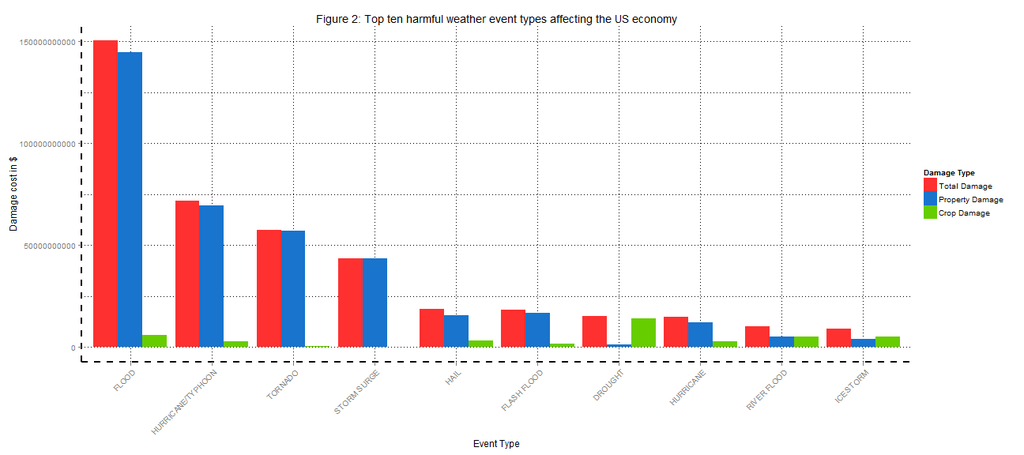

```r
plotHealth <- melt(topTenEconomy[, c("EVTYPE", "totalDamage", "propertyDamage", "cropDamage")], id.vars = 1)

ggplot(plotHealth, aes(x = reorder(EVTYPE, -value), y = value)) + geom_bar(stat = "identity", aes(fill = variable),
    position = "dodge") + theme(axis.text.x = element_text(angle = 45, hjust = 1), axis.line = element_line(size = 1,
    colour = "black", linetype = "dashed"), panel.background = element_rect(fill = "white"), panel.grid.major = element_line(colour = "black",
    linetype = "dotted"), panel.grid.minor = element_line(colour = "black", linetype = "dotted")) + xlab("Event Type") +
    ylab("Damage cost in $") + ggtitle("Figure 2: Top ten harmful weather event types affecting the US economy") +
    scale_fill_manual(name = "Damage Type", values = c("firebrick1", "dodgerblue3", "chartreuse3"), labels = c("Total Damage",
        "Property Damage", "Crop Damage"))
```

Looking at the above plot, we can deduce the following conclusions.

[output not shown]

- INJURIES
- FATALITIES
- PROPERTY DAMAGE
- CROP DAMAGE

The following code segment, creates a panel plot to accomplish the same.

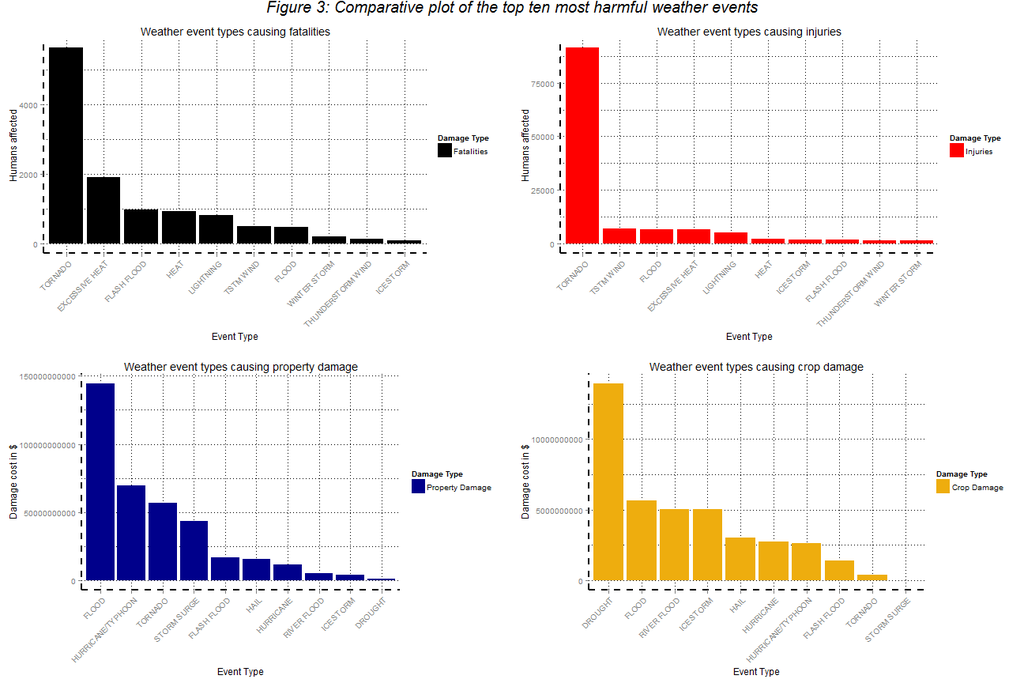

```r
plotFatalities <- melt(topTenHealth[, c("EVTYPE", "FATALITIES")], id.vars = 1)
g1 <- ggplot(plotFatalities, aes(x = reorder(EVTYPE, -value), y = value)) + geom_bar(stat = "identity",
    aes(fill = variable), position = "dodge") + theme(axis.text.x = element_text(angle = 45, hjust = 1),
    axis.line = element_line(size = 1, colour = "black", linetype = "dashed"), panel.background = element_rect(fill = "white"),
    panel.grid.major = element_line(colour = "black", linetype = "dotted"), panel.grid.minor = element_line(colour = "black",
        linetype = "dotted"), panel.background = element_rect(fill = "white")) + xlab("Event Type") +
    ylab("Humans affected") + ggtitle("Weather event types causing fatalities") + scale_fill_manual(name = "Damage Type",
    values = c("black"), labels = c("Fatalities"))


plotInjuries <- melt(topTenHealth[, c("EVTYPE", "INJURIES")], id.vars = 1)
g2 <- ggplot(plotInjuries, aes(x = reorder(EVTYPE, -value), y = value)) + geom_bar(stat = "identity",
    aes(fill = variable), position = "dodge") + theme(axis.text.x = element_text(angle = 45, hjust = 1),
    axis.line = element_line(size = 1, colour = "black", linetype = "dashed"), panel.background = element_rect(fill = "white"),
    panel.grid.major = element_line(colour = "black", linetype = "dotted"), panel.grid.minor = element_line(colour = "black",
        linetype = "dotted"), panel.background = element_rect(fill = "white")) + xlab("Event Type") +
    ylab("Humans affected") + ggtitle("Weather event types causing injuries") + scale_fill_manual(name = "Damage Type",
    values = c("red"), labels = c("Injuries"))


plotPropertyDamage <- melt(topTenEconomy[, c("EVTYPE", "propertyDamage")], id.vars = 1)
g3 <- ggplot(plotPropertyDamage, aes(x = reorder(EVTYPE, -value), y = value)) + geom_bar(stat = "identity",
    aes(fill = variable), position = "dodge") + theme(axis.text.x = element_text(angle = 45, hjust = 1),
    axis.line = element_line(size = 1, colour = "black", linetype = "dashed"), panel.background = element_rect(fill = "white"),
    panel.grid.major = element_line(colour = "black", linetype = "dotted"), panel.grid.minor = element_line(colour = "black",
        linetype = "dotted"), panel.background = element_rect(fill = "white")) + xlab("Event Type") +
    ylab("Damage cost in $") + ggtitle("Weather event types causing property damage") + scale_fill_manual(name = "Damage Type",
    values = c("blue4"), labels = c("Property Damage"))


plotCropDamage <- melt(topTenEconomy[, c("EVTYPE", "cropDamage")], id.vars = 1)
g4 <- ggplot(plotCropDamage, aes(x = reorder(EVTYPE, -value), y = value)) + geom_bar(stat = "identity",
    aes(fill = variable), position = "dodge") + theme(axis.text.x = element_text(angle = 45, hjust = 1),
    axis.line = element_line(size = 1, colour = "black", linetype = "dashed"), panel.background = element_rect(fill = "white"),
    panel.grid.major = element_line(colour = "black", linetype = "dotted"), panel.grid.minor = element_line(colour = "black",
        linetype = "dotted"), panel.background = element_rect(fill = "white")) + xlab("Event Type") +
    ylab("Damage cost in $") + ggtitle("Weather event types causing crop damage") + scale_fill_manual(name = "Damage Type",
    values = c("darkgoldenrod2"), labels = c("Crop Damage"))


grid.arrange(arrangeGrob(g1, g2, g3, g4, ncol = 2, nrow = 2), main = textGrob("Figure 3: Comparative plot of the top ten most harmful weather events",
    gp = gpar(fontsize = 20, font = 3)))
```

Looking at the above plot, we can deduce the following conclusions.

```
 FATALITIES       - Main cause of concern is TORNADO followed by EXCESSIVE HEAT and FLASH FLOOD.
 INJURIES         - Main cause of concern is TORNADO followed by TSTM WIND and FLOOD.
 PROPERTY DAMAGE  - Main cause of concern is FLOOD followed by HURRICANE/TYPHOON and TORNADO.
 CROP DAMAGE      - Main cause of concern is DROUGHT followed by FLOOD, RIVER FLOOD and ICE STORM.
```

## Conclusion

We analyzed the Storm Database provided by the U.S. National Oceanic and Atmospheric Administration and gained some interesting insights as to which weather event types pose a major threat to both the population health as well as the economy in the U.S. From our findings, we can conclude that major attention should be paid to `TORNADO`, `FLOOD` and `DROUGHT` followed by some other event types which have been mentioned in the above section.